# Heart_Disease_project

## Project: Heart Diseases Prediction Model using Machine Learning algorithms

**Cardiovascular diseases** are the leading cause of death globally, resulted in 17.9 million deaths (32.1%) in 2015, up from 12.3 million (25.8%) in 1990. It is estimated that 90% of CVD is preventable. There are many risk factors for heart diseases that we will take a closer look at.

The main objective of this study is to build a model that can **predict** the heart disease occurrence, based on a combination of features (risk factors) describing the disease. Different machine learning **classification** techniques will be implemented and compared upon standard performance metric such as accuracy and F-Score.

Contents of the Notebook:

1. Dataset structure & description
2. Analyze, identify patterns, and explore the data
3. Data preparation
4. Modelling and predicting with Machine Learning
5. Conclusion

### Import libraries

```python
# data analysis, splitting and wrangling
import pandas as pd
import numpy as np
from sklearn.model_selection import train_test_split
from sklearn.preprocessing import StandardScaler

# visualization
import matplotlib.pyplot as plt
import seaborn as sns
%matplotlib inline

# machine learning
from sklearn.linear_model import LogisticRegression
from sklearn.svm import SVC
from sklearn.tree import DecisionTreeClassifier
from sklearn.ensemble import RandomForestClassifier
from sklearn.neighbors import KNeighborsClassifier
from sklearn.naive_bayes import GaussianNB

from sklearn.metrics import fbeta_score, accuracy_score
```

### *1. Dataset structure & description*

The dataset used in this project contains 14 variables. The independent variable that needs to be predicted, 'diagnosis', determines whether a person is healthy or suffer from heart disease. Experiments with the Cleveland database have concentrated on endeavours to distinguish disease presence (values 1, 2, 3, 4) from absence (value 0). There are several missing attribute values, distinguished with symbol '?'. The header row is missing in this dataset, so the column names have to be inserted manually.

*Features information:*

- age - age in years
- sex - sex(1 = male; 0 = female)
- chest_pain - chest pain type (1 = typical angina; 2 = atypical angina; 3 = non-anginal pain; 4 = asymptomatic)
- blood_pressure - resting blood pressure (in mm Hg on admission to the hospital)
- serum_cholestoral - serum cholestoral in mg/dl
- fasting_blood_sugar - fasting blood sugar > 120 mg/dl (1 = true; 0 = false)
- electrocardiographic - resting electrocardiographic results (0 = normal; 1 = having ST-T; 2 = hypertrophy)
- max_heart_rate - maximum heart rate achieved
- induced_angina - exercise induced angina (1 = yes; 0 = no)
- ST_depression - ST depression induced by exercise relative to rest
- slope - the slope of the peak exercise ST segment (1 = upsloping; 2 = flat; 3 = downsloping)
- no_of_vessels - number of major vessels (0-3) colored by flourosopy
- thal - 3 = normal; 6 = fixed defect; 7 = reversable defect
- diagnosis - the predicted attribute - diagnosis of heart disease (angiographic disease status) (Value 0 = < 50% diameter narrowing; Value 1 = > 50% diameter narrowing)

*Types of features:*

**Categorical features** (Has two or more categories and each value in that feature can be categorised by them): **sex, chest_pain**

**Ordinal features** (Variable having relative ordering or sorting between the values): **fasting_blood_sugar, electrocardiographic, induced_angina, slope, no_of_vessels, thal, diagnosis**

**Continuous features** (Variable taking values between any two points or between the minimum or maximum values in the feature column): **age, blood_pressure, serum_cholestoral, max_heart_rate, ST_depression**

### Load data

```python
# column names in accordance with feature information
col_names = ['age','sex','chest_pain','blood_pressure','serum_cholestoral','fasting_blood_sugar', 'electrocardiographic',
             'max_heart_rate','induced_angina','ST_depression','slope','no_of_vessels','thal','diagnosis']

# read the file
df = pd.read_csv("processed.cleveland.data", names=col_names, header=None, na_values="?")

print("Number of records: {}\nNumber of variables: {}".format(df.shape[0], df.shape[1]))

# display the first 5 lines
display(df)
```

```
Number of records: 503
Number of variables: 14
```

|  | age | sex | chest_pain | blood_pressure | serum_cholestoral | fasting_blood_sugar | electrocardiographic | max_heart_rate | induced_angina | ST_depression | slope | no_of_vessels | thal | diagnosis |
| --- | --- | --- | --- | --- | --- | --- | --- | --- | --- | --- | --- | --- | --- | --- |
| 0 | 63.0 | 1.0 | 1.0 | 145.0 | 233.0 | 1.0 | 2.0 | 150.0 | 0.0 | 2.3 | 3.0 | 0.0 | 6.0 | 0 |
| 1 | 67.0 | 1.0 | 4.0 | 160.0 | 286.0 | 0.0 | 2.0 | 108.0 | 1.0 | 1.5 | 2.0 | 3.0 | 3.0 | 2 |
| 2 | 67.0 | 1.0 | 4.0 | 120.0 | 229.0 | 0.0 | 2.0 | 129.0 | 1.0 | 2.6 | 2.0 | 2.0 | 7.0 | 1 |
| 3 | 37.0 | 1.0 | 3.0 | 130.0 | 250.0 | 0.0 | 0.0 | 187.0 | 0.0 | 3.5 | 3.0 | 0.0 | 3.0 | 0 |
| 4 | 41.0 | 0.0 | 2.0 | 130.0 | 204.0 | 0.0 | 2.0 | 172.0 | 0.0 | 1.4 | 1.0 | 0.0 | 3.0 | 0 |
| 5 | 56.0 | 1.0 | 2.0 | 120.0 | 236.0 | 0.0 | 0.0 | 178.0 | 0.0 | 0.8 | 1.0 | 0.0 | 3.0 | 0 |
| 6 | 62.0 | 0.0 | 4.0 | 140.0 | 268.0 | 0.0 | 2.0 | 160.0 | 0.0 | 3.6 | 3.0 | 2.0 | 3.0 | 3 |
| 7 | 57.0 | 0.0 | 4.0 | 120.0 | 354.0 | 0.0 | 0.0 | 163.0 | 1.0 | 0.6 | 1.0 | 0.0 | 3.0 | 0 |
| 8 | 63.0 | 1.0 | 4.0 | 130.0 | 254.0 | 0.0 | 2.0 | 147.0 | 0.0 | 1.4 | 2.0 | 1.0 | 7.0 | 2 |
| 9 | 53.0 | 1.0 | 4.0 | 140.0 | 203.0 | 1.0 | 2.0 | 155.0 | 1.0 | 3.1 | 3.0 | 0.0 | 7.0 | 1 |
| 10 | 57.0 | 1.0 | 4.0 | 140.0 | 192.0 | 0.0 | 0.0 | 148.0 | 0.0 | 0.4 | 2.0 | 0.0 | 6.0 | 0 |
| 11 | 56.0 | 0.0 | 2.0 | 140.0 | 294.0 | 0.0 | 2.0 | 153.0 | 0.0 | 1.3 | 2.0 | 0.0 | 3.0 | 0 |
| 12 | 56.0 | 1.0 | 3.0 | 130.0 | 256.0 | 1.0 | 2.0 | 142.0 | 1.0 | 0.6 | 2.0 | 1.0 | 6.0 | 2 |
| 13 | 44.0 | 1.0 | 2.0 | 120.0 | 263.0 | 0.0 | 0.0 | 173.0 | 0.0 | 0.0 | 1.0 | 0.0 | 7.0 | 0 |
| 14 | 52.0 | 1.0 | 3.0 | 172.0 | 199.0 | 1.0 | 0.0 | 162.0 | 0.0 | 0.5 | 1.0 | 0.0 | 7.0 | 0 |
| 15 | 57.0 | 1.0 | 3.0 | 150.0 | 168.0 | 0.0 | 0.0 | 174.0 | 0.0 | 1.6 | 1.0 | 0.0 | 3.0 | 0 |
| 16 | 48.0 | 1.0 | 2.0 | 110.0 | 229.0 | 0.0 | 0.0 | 168.0 | 0.0 | 1.0 | 3.0 | 0.0 | 7.0 | 1 |
| 17 | 54.0 | 1.0 | 4.0 | 140.0 | 239.0 | 0.0 | 0.0 | 160.0 | 0.0 | 1.2 | 1.0 | 0.0 | 3.0 | 0 |
| 18 | 48.0 | 0.0 | 3.0 | 130.0 | 275.0 | 0.0 | 0.0 | 139.0 | 0.0 | 0.2 | 1.0 | 0.0 | 3.0 | 0 |
| 19 | 49.0 | 1.0 | 2.0 | 130.0 | 266.0 | 0.0 | 0.0 | 171.0 | 0.0 | 0.6 | 1.0 | 0.0 | 3.0 | 0 |
| 20 | 64.0 | 1.0 | 1.0 | 110.0 | 211.0 | 0.0 | 2.0 | 144.0 | 1.0 | 1.8 | 2.0 | 0.0 | 3.0 | 0 |
| 21 | 58.0 | 0.0 | 1.0 | 150.0 | 283.0 | 1.0 | 2.0 | 162.0 | 0.0 | 1.0 | 1.0 | 0.0 | 3.0 | 0 |
| 22 | 58.0 | 1.0 | 2.0 | 120.0 | 284.0 | 0.0 | 2.0 | 160.0 | 0.0 | 1.8 | 2.0 | 0.0 | 3.0 | 1 |
| 23 | 58.0 | 1.0 | 3.0 | 132.0 | 224.0 | 0.0 | 2.0 | 173.0 | 0.0 | 3.2 | 1.0 | 2.0 | 7.0 | 3 |
| 24 | 60.0 | 1.0 | 4.0 | 130.0 | 206.0 | 0.0 | 2.0 | 132.0 | 1.0 | 2.4 | 2.0 | 2.0 | 7.0 | 4 |
| 25 | 50.0 | 0.0 | 3.0 | 120.0 | 219.0 | 0.0 | 0.0 | 158.0 | 0.0 | 1.6 | 2.0 | 0.0 | 3.0 | 0 |
| 26 | 58.0 | 0.0 | 3.0 | 120.0 | 340.0 | 0.0 | 0.0 | 172.0 | 0.0 | 0.0 | 1.0 | 0.0 | 3.0 | 0 |
| 27 | 66.0 | 0.0 | 1.0 | 150.0 | 226.0 | 0.0 | 0.0 | 114.0 | 0.0 | 2.6 | 3.0 | 0.0 | 3.0 | 0 |
| 28 | 43.0 | 1.0 | 4.0 | 150.0 | 247.0 | 0.0 | 0.0 | 171.0 | 0.0 | 1.5 | 1.0 | 0.0 | 3.0 | 0 |
| 29 | 40.0 | 1.0 | 4.0 | 110.0 | 167.0 | 0.0 | 2.0 | 114.0 | 1.0 | 2.0 | 2.0 | 0.0 | 7.0 | 3 |
| ... | ... | ... | ... | ... | ... | ... | ... | ... | ... | ... | ... | ... | ... | ... |
| 473 | 41.0 | 0.0 | 3.0 | 112.0 | 268.0 | 0.0 | 2.0 | 172.0 | 1.0 | 0.0 | 1.0 | 0.0 | 3.0 | 0 |
| 474 | 54.0 | 0.0 | 3.0 | 108.0 | 267.0 | 0.0 | 2.0 | 167.0 | 0.0 | 0.0 | 1.0 | 0.0 | 3.0 | 0 |
| 475 | 39.0 | 0.0 | 3.0 | 94.0 | 199.0 | 0.0 | 0.0 | 179.0 | 0.0 | 0.0 | 1.0 | 0.0 | 3.0 | 0 |
| 476 | 53.0 | 1.0 | 4.0 | 123.0 | 282.0 | 0.0 | 0.0 | 95.0 | 1.0 | 2.0 | 2.0 | 2.0 | 7.0 | 3 |
| 477 | 63.0 | 0.0 | 4.0 | 108.0 | 269.0 | 0.0 | 0.0 | 169.0 | 1.0 | 1.8 | 2.0 | 2.0 | 3.0 | 1 |
| 478 | 34.0 | 0.0 | 2.0 | 118.0 | 210.0 | 0.0 | 0.0 | 192.0 | 0.0 | 0.7 | 1.0 | 0.0 | 3.0 | 0 |
| 479 | 47.0 | 1.0 | 4.0 | 112.0 | 204.0 | 0.0 | 0.0 | 143.0 | 0.0 | 0.1 | 1.0 | 0.0 | 3.0 | 0 |
| 480 | 67.0 | 0.0 | 3.0 | 152.0 | 277.0 | 0.0 | 0.0 | 172.0 | 0.0 | 0.0 | 1.0 | 1.0 | 3.0 | 0 |
| 481 | 54.0 | 1.0 | 4.0 | 110.0 | 206.0 | 0.0 | 2.0 | 108.0 | 1.0 | 0.0 | 2.0 | 1.0 | 3.0 | 3 |
| 482 | 66.0 | 1.0 | 4.0 | 112.0 | 212.0 | 0.0 | 2.0 | 132.0 | 1.0 | 0.1 | 1.0 | 1.0 | 3.0 | 2 |
| 483 | 52.0 | 0.0 | 3.0 | 136.0 | 196.0 | 0.0 | 2.0 | 169.0 | 0.0 | 0.1 | 2.0 | 0.0 | 3.0 | 0 |
| 484 | 55.0 | 0.0 | 4.0 | 180.0 | 327.0 | 0.0 | 1.0 | 117.0 | 1.0 | 3.4 | 2.0 | 0.0 | 3.0 | 2 |
| 485 | 49.0 | 1.0 | 3.0 | 118.0 | 149.0 | 0.0 | 2.0 | 126.0 | 0.0 | 0.8 | 1.0 | 3.0 | 3.0 | 1 |
| 486 | 74.0 | 0.0 | 2.0 | 120.0 | 269.0 | 0.0 | 2.0 | 121.0 | 1.0 | 0.2 | 1.0 | 1.0 | 3.0 | 0 |
| 487 | 54.0 | 0.0 | 3.0 | 160.0 | 201.0 | 0.0 | 0.0 | 163.0 | 0.0 | 0.0 | 1.0 | 1.0 | 3.0 | 0 |
| 488 | 54.0 | 1.0 | 4.0 | 122.0 | 286.0 | 0.0 | 2.0 | 116.0 | 1.0 | 3.2 | 2.0 | 2.0 | 3.0 | 3 |
| 489 | 56.0 | 1.0 | 4.0 | 130.0 | 283.0 | 1.0 | 2.0 | 103.0 | 1.0 | 1.6 | 3.0 | 0.0 | 7.0 | 2 |
| 490 | 46.0 | 1.0 | 4.0 | 120.0 | 249.0 | 0.0 | 2.0 | 144.0 | 0.0 | 0.8 | 1.0 | 0.0 | 7.0 | 1 |
| 491 | 49.0 | 0.0 | 2.0 | 134.0 | 271.0 | 0.0 | 0.0 | 162.0 | 0.0 | 0.0 | 2.0 | 0.0 | 3.0 | 0 |
| 492 | 42.0 | 1.0 | 2.0 | 120.0 | 295.0 | 0.0 | 0.0 | 162.0 | 0.0 | 0.0 | 1.0 | 0.0 | 3.0 | 0 |
| 493 | 41.0 | 1.0 | 2.0 | 110.0 | 235.0 | 0.0 | 0.0 | 153.0 | 0.0 | 0.0 | 1.0 | 0.0 | 3.0 | 0 |
| 494 | 41.0 | 0.0 | 2.0 | 126.0 | 306.0 | 0.0 | 0.0 | 163.0 | 0.0 | 0.0 | 1.0 | 0.0 | 3.0 | 0 |
| 495 | 49.0 | 0.0 | 4.0 | 130.0 | 269.0 | 0.0 | 0.0 | 163.0 | 0.0 | 0.0 | 1.0 | 0.0 | 3.0 | 0 |
| 496 | 61.0 | 1.0 | 1.0 | 134.0 | 234.0 | 0.0 | 0.0 | 145.0 | 0.0 | 2.6 | 2.0 | 2.0 | 3.0 | 2 |
| 497 | 60.0 | 0.0 | 3.0 | 120.0 | 178.0 | 1.0 | 0.0 | 96.0 | 0.0 | 0.0 | 1.0 | 0.0 | 3.0 | 0 |
| 498 | 67.0 | 1.0 | 4.0 | 120.0 | 237.0 | 0.0 | 0.0 | 71.0 | 0.0 | 1.0 | 2.0 | 0.0 | 3.0 | 2 |
| 499 | 58.0 | 1.0 | 4.0 | 100.0 | 234.0 | 0.0 | 0.0 | 156.0 | 0.0 | 0.1 | 1.0 | 1.0 | 7.0 | 2 |
| 500 | 47.0 | 1.0 | 4.0 | 110.0 | 275.0 | 0.0 | 2.0 | 118.0 | 1.0 | 1.0 | 2.0 | 1.0 | 3.0 | 1 |
| 501 | 52.0 | 1.0 | 4.0 | 125.0 | 212.0 | 0.0 | 0.0 | 168.0 | 0.0 | 1.0 | 1.0 | 2.0 | 7.0 | 3 |
| 502 | 62.0 | 1.0 | 2.0 | 128.0 | 208.0 | 1.0 | 2.0 | 140.0 | 0.0 | 0.0 | 1.0 | 0.0 | 3.0 | 0 |

503 rows × 14 columns

```python
# Display a description of the total dataset
display(df.describe())
```

|  | age | sex | chest_pain | blood_pressure | serum_cholestoral | fasting_blood_sugar | electrocardiographic | max_heart_rate | induced_angina | ST_depression | slope | no_of_vessels | thal | diagnosis |
| --- | --- | --- | --- | --- | --- | --- | --- | --- | --- | --- | --- | --- | --- | --- |
| count | 503.000000 | 503.000000 | 503.000000 | 503.000000 | 503.000000 | 503.000000 | 503.000000 | 503.000000 | 503.000000 | 503.000000 | 503.000000 | 497.000000 | 500.000000 | 503.000000 |
| mean | 54.258449 | 0.675944 | 3.176938 | 131.262425 | 248.552684 | 0.147117 | 1.035785 | 149.648111 | 0.333996 | 1.008748 | 1.588469 | 0.692153 | 4.736000 | 0.936382 |
| std | 9.029434 | 0.468487 | 0.948108 | 18.046937 | 51.780612 | 0.354575 | 0.995364 | 23.208166 | 0.472108 | 1.172716 | 0.608396 | 0.952394 | 1.947792 | 1.223902 |
| min | 29.000000 | 0.000000 | 1.000000 | 94.000000 | 126.000000 | 0.000000 | 0.000000 | 71.000000 | 0.000000 | 0.000000 | 1.000000 | 0.000000 | 3.000000 | 0.000000 |
| 25% | 47.500000 | 0.000000 | 3.000000 | 120.000000 | 212.000000 | 0.000000 | 0.000000 | 133.000000 | 0.000000 | 0.000000 | 1.000000 | 0.000000 | 3.000000 | 0.000000 |
| 50% | 55.000000 | 1.000000 | 3.000000 | 130.000000 | 245.000000 | 0.000000 | 2.000000 | 153.000000 | 0.000000 | 0.600000 | 2.000000 | 0.000000 | 3.000000 | 0.000000 |
| 75% | 61.000000 | 1.000000 | 4.000000 | 140.000000 | 277.000000 | 0.000000 | 2.000000 | 166.000000 | 1.000000 | 1.600000 | 2.000000 | 1.000000 | 7.000000 | 2.000000 |
| max | 77.000000 | 1.000000 | 4.000000 | 200.000000 | 564.000000 | 1.000000 | 2.000000 | 202.000000 | 1.000000 | 6.200000 | 3.000000 | 3.000000 | 7.000000 | 4.000000 |

```python
df.info()
```

```
<class 'pandas.core.frame.DataFrame'>
RangeIndex: 503 entries, 0 to 502
Data columns (total 14 columns):
age                     503 non-null float64
sex                     503 non-null float64
chest_pain              503 non-null float64
blood_pressure          503 non-null float64
serum_cholestoral       503 non-null float64
fasting_blood_sugar     503 non-null float64
electrocardiographic    503 non-null float64
max_heart_rate          503 non-null float64
induced_angina          503 non-null float64
ST_depression           503 non-null float64
slope                   503 non-null float64
no_of_vessels           497 non-null float64
thal                    500 non-null float64
diagnosis               503 non-null int64
dtypes: float64(13), int64(1)
memory usage: 55.1 KB
```

There are only 9 missing values in this dataset and all variables are recognized as numeric. From dataset description, we know, however, that most of features are categorical and it's necessary to distinguish them.

```python
# extract numeric columns and find categorical ones
numeric_columns = ['serum_cholestoral', 'max_heart_rate', 'age', 'blood_pressure', 'ST_depression']
categorical_columns = [c for c in df.columns if c not in numeric_columns]
print(categorical_columns)
```

```
['sex', 'chest_pain', 'fasting_blood_sugar', 'electrocardiographic', 'induced_angina', 'slope', 'no_of_vessels', 'thal', 'diagnosis']
```

## *2.Analyze features, identify patterns, and explore the data*

### Target value

Knowing the distribution of target value is vital for choosing appropriate accuracy metrics and consequently properly assess different machine learning models.

```python
# count values of explained variable
df.diagnosis.value_counts()
```

```
0    272
1     92
3     61
2     58
4     20
Name: diagnosis, dtype: int64
```

Since the values 1-4 indicate that a disease is present, it's reasonable to pull them together.

```python
# create a boolean vector and map it with corresponding values (True=1, False=0)
df.diagnosis = (df.diagnosis != 0).astype(int)
df.diagnosis.value_counts()
```

```
0    272
1    231
Name: diagnosis, dtype: int64
```

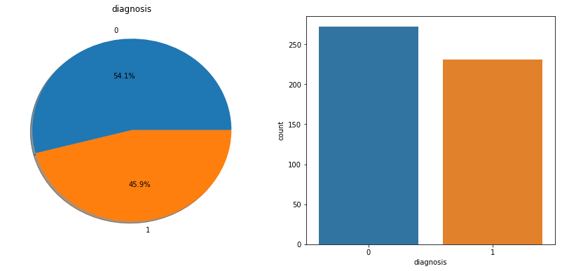

```python
# create two plots side by side
f, ax = plt.subplots(1,2,figsize=(14,6))
df['diagnosis'].value_counts().plot.pie(autopct='%1.1f%%', ax=ax[0], shadow=True)
ax[0].set_title('diagnosis')
ax[0].set_ylabel('')
sns.countplot('diagnosis', data=df, ax=ax[1])
plt.show()
```

Now the distribution of target value is almost equal, so using standard metrics in further machine learning modelling like *accuracy* and *AUC* is justified.

### Numeric features

There are 5 numeric columns, so let's take care of them first. Outliers occurrence in the dataset may be a result of wrong input and create undesired noise, thus our role is to evaluate their substance. A data point is considered as an outlier when it falls outside 3 standard deviations.

```python
# view of descriptive statistics
df[numeric_columns].describe()
```

|  | serum_cholestoral | max_heart_rate | age | blood_pressure | ST_depression |
| --- | --- | --- | --- | --- | --- |
| count | 503.000000 | 503.000000 | 503.000000 | 503.000000 | 503.000000 |
| mean | 248.552684 | 149.648111 | 54.258449 | 131.262425 | 1.008748 |
| std | 51.780612 | 23.208166 | 9.029434 | 18.046937 | 1.172716 |
| min | 126.000000 | 71.000000 | 29.000000 | 94.000000 | 0.000000 |
| 25% | 212.000000 | 133.000000 | 47.500000 | 120.000000 | 0.000000 |
| 50% | 245.000000 | 153.000000 | 55.000000 | 130.000000 | 0.600000 |
| 75% | 277.000000 | 166.000000 | 61.000000 | 140.000000 | 1.600000 |
| max | 564.000000 | 202.000000 | 77.000000 | 200.000000 | 6.200000 |

All extreme (min/max) values could occur in a real clinical scenario, hence the decision to keep them as they are.

We can gain some intuition about relationships amongst numeric features by plotting each pair in a scattered form. To do this efficiently, *pairplot* method from Seaborn library comes in handy.

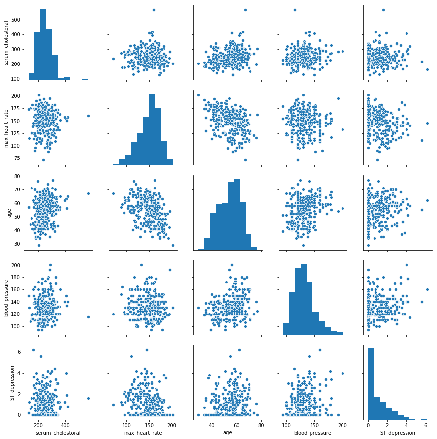

```python
# create a pairplot
sns.pairplot(df[numeric_columns])
plt.show()
```

Seeing above plots, I infer that none of displayed value pairs is having an explicitly high correlation, so there is no necessity to ditch any feature at this stage. I also notice a negative correlation between 'age' and 'max_heart_rate' and positive correlation between 'age' and 'blood_pressure', what is intuitive.

A correlation matrix will make us sure whether the above is correct.

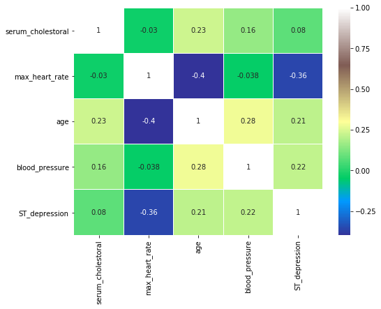

```python
# create a correlation heatmap
sns.heatmap(df[numeric_columns].corr(),annot=True, cmap='terrain', linewidths=0.1)
fig=plt.gcf()
fig.set_size_inches(8,6)
plt.show()
```

Apart from two aforementioned relations, there is one more important dependency: 'max_heart_rate' and 'ST_depression'. The conclusion comes up that both features, 'age' and 'max_heart_rate', will play an important role in predicting heart disease. Let's take a look at their distributions.

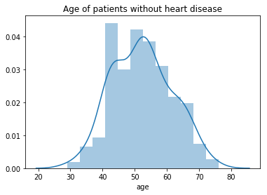

```python
# create four distplots
sns.distplot(df[df['diagnosis']==0].age)
plt.title('Age of patients without heart disease')
plt.show()
```

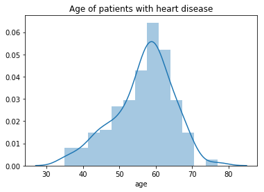

```python
sns.distplot(df[df['diagnosis']==1].age)
plt.title('Age of patients with heart disease')
plt.show()
```

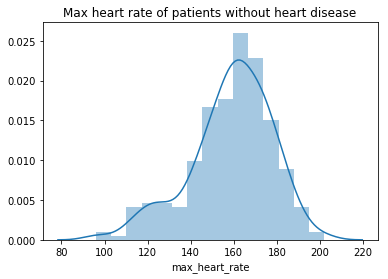

```python
sns.distplot(df[df['diagnosis']==0].max_heart_rate)
plt.title('Max heart rate of patients without heart disease')
plt.show()
```

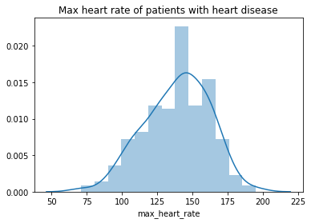

```python
sns.distplot(df[df['diagnosis']==1].max_heart_rate)
plt.title('Max heart rate of patients with heart disease')
plt.show()
```

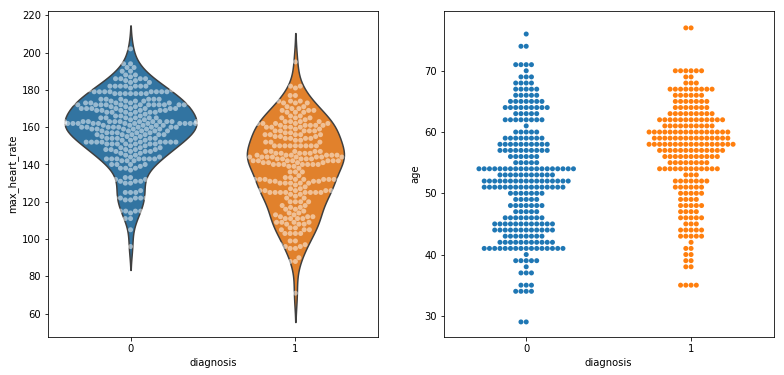

```python
# create swarmplot inside the violinplot
plt.figure(figsize=(13,6))
plt.subplot(121)
sns.violinplot(x="diagnosis", y="max_heart_rate", data=df, inner=None)
sns.swarmplot(x='diagnosis', y='max_heart_rate', data=df, color='w', alpha=0.5)
plt.subplot(122)
sns.swarmplot(x='diagnosis', y='age', data=df)
plt.show()
```

### Categorical features

Let's take a closer look at categorical variables and see how they impact our target.

```python
# count ill vs healthy people grouped by sex
df.groupby(['sex','diagnosis'])['diagnosis'].count()
```

```
sex  diagnosis
0.0  0            122
     1             41
1.0  0            150
     1            190
Name: diagnosis, dtype: int64
```

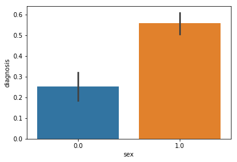

```python
sns.barplot(x="sex", y="diagnosis", data=df)
```

```python
# average number of diagnosed people grouped by number of blood vessels detected by fluoroscopy
df[['no_of_vessels','diagnosis']].groupby('no_of_vessels').mean()
```

| no_of_vessels | diagnosis |
| --- | --- |
| 0.0 | 0.260417 |
| 1.0 | 0.657658 |
| 2.0 | 0.819672 |
| 3.0 | 0.837838 |

[figure not shown]

```python
# create pairplot and two barplots
plt.figure(figsize=(16,6))
plt.subplot(131)
sns.pointplot(x="sex", y="diagnosis", hue='chest_pain', data=df)
plt.legend(['male = 1', 'female = 0'])
plt.subplot(132)
sns.barplot(x="induced_angina", y="diagnosis", data=df)
plt.legend(['yes = 1', 'no = 0'])
plt.subplot(133)
sns.countplot(x="slope", hue='diagnosis', data=df)
plt.show()
```

#### Observations:

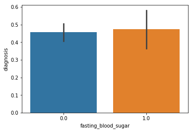

```python
# create a barplot
sns.barplot(x="fasting_blood_sugar", y="diagnosis", data=df)
```

Almost even distribution suggests 'fasting blood sugar' to be a very weak feature for our prediction, therefore it could be excluded from our model. It is not likely that leaving this variable will improve our model accuracy, yet it shouldn't make it worse too. I decide to keep this variable as it is and confirm my hypothesis through checking feature importance of a few models.

## 3.Data Preparation

In order to make our dataset compatible with machine learning algorithms contained in Sci-kit Learn library, first of all, we need to handle all missing data.

There are many options we could consider when replacing a missing value, for example:

- A constant value that has meaning within the domain, such as 0, distinct from all other values
- A value from another randomly selected record
- A mean, median or mode value for the column
- A value estimated by another predictive model

```python
# show columns having missing values
df.isnull().sum()
```

```
age                     0
sex                     0
chest_pain              0
blood_pressure          0
serum_cholestoral       0
fasting_blood_sugar     0
electrocardiographic    0
max_heart_rate          0
induced_angina          0
ST_depression           0
slope                   0
no_of_vessels           6
thal                    3
diagnosis               0
dtype: int64
```

Both columns containing missing values are categorical. In such case, mode (most frequently occurring value in a given vector) is usually used for filling 'nans'. Let's follow this solution.

```python
# fill missing values with mode
df['no_of_vessels'].fillna(df['no_of_vessels'].mode()[0], inplace=True)
df['thal'].fillna(df['thal'].mode()[0], inplace=True)
```

Having clean data, a label can be separated from the data frame. It is also a good moment to split our data train and test sets. I will allocate 30% of the entire data to test set, which is typically considered as a standard split for this size of dataset.

```python
# extract the target variable
X, y = df.iloc[:, :-1], df.iloc[:, -1]
print(X.shape)
print(y.shape)
```

```
(503, 13)
(503L,)
```

```python
# split the data
X_train, X_test, y_train, y_test = train_test_split(X, y, test_size=0.3, random_state=2606)
print ("train_set_x shape: " + str(X_train.shape))
print ("train_set_y shape: " + str(y_train.shape))
print ("test_set_x shape: " + str(X_test.shape))
print ("test_set_y shape: " + str(y_test.shape))
```

```
train_set_x shape: (352, 13)
train_set_y shape: (352L,)
test_set_x shape: (151, 13)
test_set_y shape: (151L,)
```

Data needs to be normalized or standardized before applying to machine learning algorithms. Standardization scales the data and gives information on how many standard deviations the data is placed from its mean value. Effectively, the mean of the data (µ) is 0 and the standard deviation (σ) is 1.

```python
# scale feature matrices
scaler = StandardScaler()
X_train = scaler.fit_transform(X_train)
X_test = scaler.transform(X_test)
```

## 4. Modelling and predicting with Machine Learning

The main goal of the entire project is to predict heart disease occurrence with the highest accuracy. In order to achieve this, we will test several classification algorithms. This section includes all results obtained from the study and introduces the best performer according to accuracy metric. I have chosen several algorithms typical for solving supervised learning problems throughout classification methods.

First of all, let's equip ourselves with a handy tool that benefits from the cohesion of SciKit Learn library and formulate a general function for training our models. The reason for displaying accuracy on both, train and test sets, is to allow us to evaluate whether the model overfits or underfits the data (so-called bias/variance tradeoff).

```python
def train_model(X_train, y_train, X_test, y_test, classifier, **kwargs):

    """
    Fit the chosen model and print out the score.

    """

    # instantiate model
    model = classifier(**kwargs)

    # train model
    model.fit(X_train,y_train)

    # check accuracy and print out the results
    fit_accuracy = model.score(X_train, y_train)
    test_accuracy = model.score(X_test, y_test)
    predictions_train = model.predict(X_train)
    predictions_test = model.predict(X_test)


    print "Train accuracy: {:0.2f}%".format(fit_accuracy*100)
    print "Test accuracy:{:.2f}%" .format(test_accuracy*100)
    print("Train F-Score:{}" .format(fbeta_score(y_train,predictions_train,0.5)))
    print("Test F-Score:{}" .format(fbeta_score(y_test,predictions_test,0.5)))

    return model
```

### K-Nearest Neighbours (KNN)

K-Nearest Neighbors algorithm is a non-parametric method used for classification and regression. The principle behind nearest neighbour methods is to find a predefined number of training samples closest in distance to the new point and predict the label from these.

```python
# KNN
model = train_model(X_train, y_train, X_test, y_test, KNeighborsClassifier)
```

```
Train accuracy: 90.62%
Test accuracy:83.44%
Train F-Score:0.912547528517
Test F-Score:0.8
```

Despite its simplicity, the result is very promising. Let's see if KNN can perform even better by trying different 'n_neighbours' inputs.

```python
# Seek optimal 'n_neighbours' parameter
for i in range(1,10):
    print("n_neigbors = "+str(i))
    train_model(X_train, y_train, X_test, y_test, KNeighborsClassifier, n_neighbors=i)
```

```
n_neigbors = 1
Train accuracy: 100.00%
Test accuracy:88.08%
Train F-Score:1.0
Test F-Score:0.85798816568
n_neigbors = 2
Train accuracy: 94.32%
Test accuracy:80.13%
Train F-Score:0.973154362416
Test F-Score:0.802919708029
n_neigbors = 3
Train accuracy: 93.18%
Test accuracy:80.79%
Train F-Score:0.924369747899
Test F-Score:0.765027322404
n_neigbors = 4
Train accuracy: 90.91%
Test accuracy:81.46%
Train F-Score:0.93288590604
Test F-Score:0.791925465839
n_neigbors = 5
Train accuracy: 90.62%
Test accuracy:83.44%
Train F-Score:0.912547528517
Test F-Score:0.8
n_neigbors = 6
Train accuracy: 90.91%
Test accuracy:85.43%
Train F-Score:0.929614873838
Test F-Score:0.83850931677
n_neigbors = 7
Train accuracy: 90.91%
Test accuracy:84.11%
Train F-Score:0.920205920206
Test F-Score:0.818181818182
n_neigbors = 8
Train accuracy: 90.06%
Test accuracy:84.77%
Train F-Score:0.918097754293
Test F-Score:0.828220858896
n_neigbors = 9
Train accuracy: 89.49%
Test accuracy:84.77%
Train F-Score:0.902688860435
Test F-Score:0.823353293413
```

### Decision Trees

Decision Trees algorithm creates a model that predicts the value of a target variable by learning simple decision rules inferred from the data features. It is simple to understand and interpret and it's possible to visualize how important a particular feature was for our tree.

```
Train accuracy: 100.00%
Test accuracy:92.72%
Train F-Score:1.0
Test F-Score:0.920245398773
```

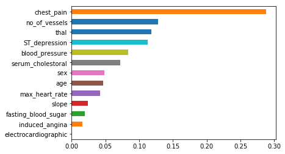

```python
# Decision Tree
model = train_model(X_train, y_train, X_test, y_test, DecisionTreeClassifier, random_state=2606)

# plot feature importances
pd.Series(model.feature_importances_,X.columns).sort_values(ascending=True).plot.barh()
```

```python
# Check optimal 'max_depth' parameter
for i in range(1,8):
    print("max_depth = "+str(i))
    train_model(X_train, y_train, X_test, y_test, DecisionTreeClassifier, max_depth=i, random_state=2606)
```

```
max_depth = 1
Train accuracy: 76.42%
Test accuracy:76.16%
Train F-Score:0.743321718931
Test F-Score:0.724852071006
max_depth = 2
Train accuracy: 79.83%
Test accuracy:77.48%
Train F-Score:0.824508320726
Test F-Score:0.770676691729
max_depth = 3
Train accuracy: 86.93%
Test accuracy:84.11%
Train F-Score:0.880420499343
Test F-Score:0.833333333333
max_depth = 4
Train accuracy: 90.34%
Test accuracy:81.46%
Train F-Score:0.929443690638
Test F-Score:0.796178343949
max_depth = 5
Train accuracy: 93.18%
Test accuracy:81.46%
Train F-Score:0.952693823916
Test F-Score:0.805369127517
max_depth = 6
Train accuracy: 93.47%
Test accuracy:83.44%
Train F-Score:0.957727873184
Test F-Score:0.833333333333
max_depth = 7
Train accuracy: 94.60%
Test accuracy:84.77%
Train F-Score:0.974632843792
Test F-Score:0.863309352518
```

### Logistic Regression

Logistic regression is a basic technique in statistical analysis that attempts to predict a data value based on prior observations. A logistic regression algorithm looks at the relationship between a dependent variable and one or more dependent variables.

```python
# Logistic Regression
model = train_model(X_train, y_train, X_test, y_test, LogisticRegression)
```

```
Train accuracy: 87.22%
Test accuracy:82.78%
Train F-Score:0.872020075282
Test F-Score:0.798816568047
```

Slight difference between train and test score tells us as that model performs at the optimal level. Although the result itself is slightly lower than KNN, yet is still satisfactory.

### Gaussian Naive Bayes

In machine learning, naive Bayes classifiers are a family of simple probabilistic classifiers based on applying Bayes' theorem with strong (naive) independence assumptions between the features.

```python
#Gaussian Naive Bayes
model = train_model(X_train, y_train, X_test, y_test, GaussianNB)
```

```
Train accuracy: 87.78%
Test accuracy:82.12%
Train F-Score:0.886157826649
Test F-Score:0.789473684211
```

### Support Vector Machines

Support Vector Machines are perhaps one of the most popular machine learning algorithms. They are the go-to method for a high-performing algorithm with a little tuning. At first, let's try it on default settings.

```python
# Support Vector Machines
model = train_model(X_train, y_train, X_test, y_test, SVC)
```

```
Train accuracy: 93.47%
Test accuracy:84.77%
Train F-Score:0.947503201024
Test F-Score:0.823353293413
```

The above numbers are not remarkable by any means. I will adjust two parameters, "C", and 'kernel' to take full advantage of SVM power.

```python
# tuned SVM
model = train_model(X_train, y_train, X_test, y_test, SVC, C=0.05, kernel='linear')
```

```
Train accuracy: 85.80%
Test accuracy:84.77%
Train F-Score:0.864759427828
Test F-Score:0.828220858896
```

### Random Forests

Random forests are an ensemble learning method for classification, regression and other tasks, that operate by constructing a multitude of decision trees at training time and outputting the class that is the mode of the classes (classification) or mean prediction (regression) of the individual trees.

```
Train accuracy: 99.72%
Test accuracy:94.04%
Train F-Score:0.998781973203
Test F-Score:0.928143712575
```

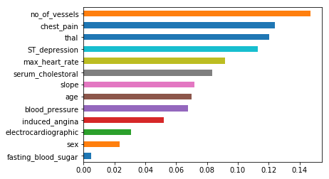

```python
# Random Forests
model = train_model(X_train, y_train, X_test, y_test, RandomForestClassifier, random_state=2606)
pd.Series(model.feature_importances_,X.columns).sort_values(ascending=True).plot.barh()
```

```python
# tuned Random Forests
model = train_model(X_train, y_train, X_test, y_test, RandomForestClassifier, n_estimators=110, random_state=2606)
```

```
Train accuracy: 100.00%
Test accuracy:91.39%
Train F-Score:1.0
Test F-Score:0.891812865497
```

While it is typical for Random Forests to perfectly learn and fit into training data, the test accuracy achieved outstanding 91.39%!

## 5. Conclusion

The goal of the project was to compare different machine learning algorithms and predict if a certain person, given various personal characteristics and symptoms, will get heart disease or not. Here are the final results.

```python
# initialize an empty list
accuracy1 = []
accuracy2 = []
# list of algorithms names
classifiers = ['KNN', 'Decision Trees', 'Logistic Regression', 'Naive Bayes', 'SVM', 'Random Forests']

# list of algorithms with parameters
models = [KNeighborsClassifier(n_neighbors=5), DecisionTreeClassifier(max_depth=6, random_state=2606), LogisticRegression(),
        GaussianNB(), SVC(C=0.05, kernel='linear'), RandomForestClassifier(n_estimators=110, random_state=2606)]

# loop through algorithms and append the score into the list
for i in models:
    model = i
    model.fit(X_train, y_train)
    score = model.score(X_test, y_test)
    score1=model.score(X_train,y_train)
    accuracy1.append(score1)
    accuracy2.append(score)
```

```python
# create a dataframe from accuracy results
summary = pd.DataFrame({ 'Train_Accuracy':accuracy1, 'Test_Accuracy':accuracy2}, index=classifiers)
summary
```

|  | Test_Accuracy | Train_Accuracy |
| --- | --- | --- |
| KNN | 0.834437 | 0.906250 |
| Decision Trees | 0.834437 | 0.934659 |
| Logistic Regression | 0.827815 | 0.872159 |
| Naive Bayes | 0.821192 | 0.877841 |
| SVM | 0.847682 | 0.857955 |
| Random Forests | 0.913907 | 1.000000 |

It does not come as a surprise that the more complex algorithms like SVM and Random Forests generated better results compared to the basic ones. It is worth to emphasize that in most cases hyperparameter tuning is essential to achieve robust results out of these techniques. By producing decent results, simpler methods proved to be useful as well.

Machine learning has absolutely bright future in medical field. Just imagine a place where heart disease experts are not available. With just basic information about a certain patient's medical history, we may quite accurately predict whether a disease will occur or not.